# R Notebook

```r
library(GGally)
```

```r
diamonds <- read_csv("diamonds.csv")
```

```r
model <- lm(carat ~ x + y + z, data = diamonds)
```

```r
summary(model)
```

```
Call:
lm(formula = carat ~ x + y + z, data = diamonds)

Residuals:
    Min      1Q  Median      3Q     Max
-2.2806 -0.0695 -0.0280  0.0590  3.8168

Coefficients:
             Estimate Std. Error  t value Pr(>|t|)
(Intercept) -1.566773   0.002341 -669.401  < 2e-16 ***
x            0.359054   0.002297  156.316  < 2e-16 ***
y            0.005154   0.001769    2.914  0.00357 **
z            0.078378   0.002666   29.396  < 2e-16 ***
---
Signif. codes:  0 ‘***’ 0.001 ‘**’ 0.01 ‘*’ 0.05 ‘.’ 0.1 ‘ ’ 1

Residual standard error: 0.1043 on 53936 degrees of freedom
Multiple R-squared:  0.9516,    Adjusted R-squared:  0.9516
F-statistic: 3.536e+05 on 3 and 53936 DF,  p-value: < 2.2e-16
```

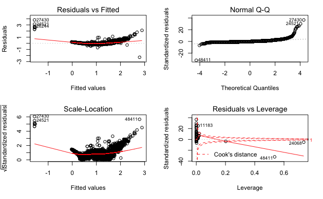

```r
par(mfrow = c(2,2))
plot(model)
```

p-values are much smaller than 0.05. I would say that the residuals are fairly independent from each other, as they are more or less scattered around the value 0. However, we can see some dependency for the biggest fitted values. Residuals distribution is normal from the theoretical quantile -4 to 3. It is not normal for the outliers between 3 and 4. The residuals variation shows some increase in the extremes, but it is not much. Overall I would say we can trust the p-values, as all this conditions are fulfilled.

| carat | x | y | z |
| --- | --- | --- | --- |
| 0.23 | 3.95 | 3.98 | 2.43 |
| 0.21 | 3.89 | 3.84 | 2.31 |
| 0.23 | 4.05 | 4.07 | 2.31 |
| 0.29 | 4.20 | 4.23 | 2.63 |
| 0.31 | 4.34 | 4.35 | 2.75 |
| 0.24 | 3.94 | 3.96 | 2.48 |
| 0.24 | 3.95 | 3.98 | 2.47 |
| 0.26 | 4.07 | 4.11 | 2.53 |
| 0.22 | 3.87 | 3.78 | 2.49 |
| 0.23 | 4.00 | 4.05 | 2.39 |

[output cut: 990 more lines]

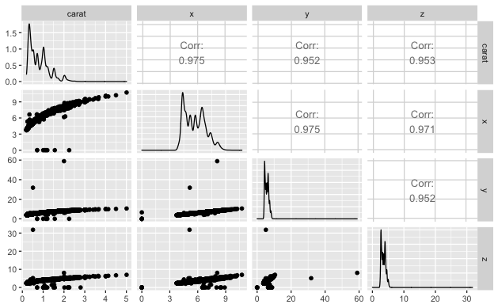

```r
ggpairs(diamonds_2)
```

There is a big correlation among all the variables.

| X1 | carat | cut | color | clarity | depth | table | price |
| --- | --- | --- | --- | --- | --- | --- | --- |
| 1 | 0.23 | Ideal | E | SI2 | 61.5 | 55.0 | 326 |
| 2 | 0.21 | Premium | E | SI1 | 59.8 | 61.0 | 326 |
| 3 | 0.23 | Good | E | VS1 | 56.9 | 65.0 | 327 |
| 4 | 0.29 | Premium | I | VS2 | 62.4 | 58.0 | 334 |
| 5 | 0.31 | Good | J | SI2 | 63.3 | 58.0 | 335 |
| 6 | 0.24 | Very Good | J | VVS2 | 62.8 | 57.0 | 336 |
| 7 | 0.24 | Very Good | I | VVS1 | 62.3 | 57.0 | 336 |
| 8 | 0.26 | Very Good | H | SI1 | 61.9 | 55.0 | 337 |
| 9 | 0.22 | Fair | E | VS2 | 65.1 | 61.0 | 337 |
| 10 | 0.23 | Very Good | H | VS1 | 59.4 | 61.0 | 338 |

[output cut: 990 more lines]

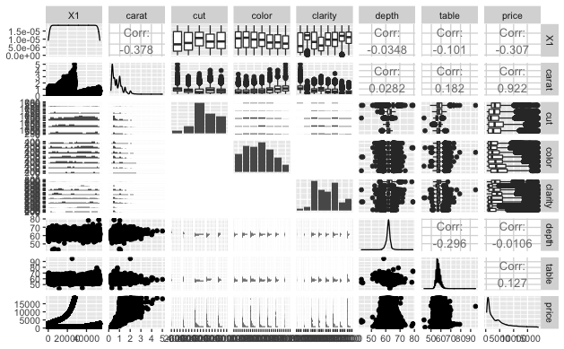

```r
ggpairs(diamonds_3)
```

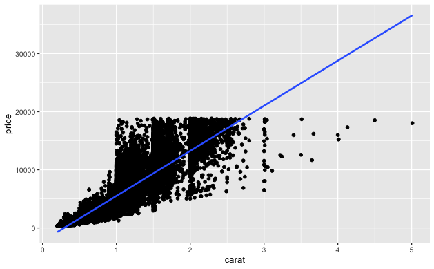

```r
diamonds_3 %>%
  ggplot(aes(x = carat, y = price)) +
  geom_point() +
  geom_smooth(method = "lm", se = FALSE)
```

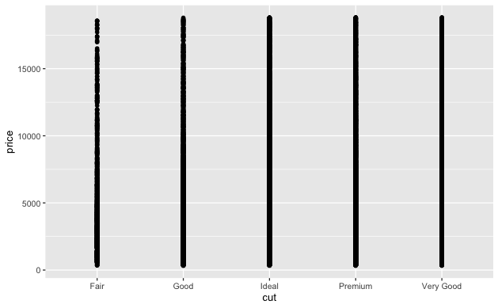

```r
diamonds_3 %>%
  ggplot(aes(x = cut, y = price)) +
  geom_point() +
  geom_smooth(method = "lm", se = FALSE)
```

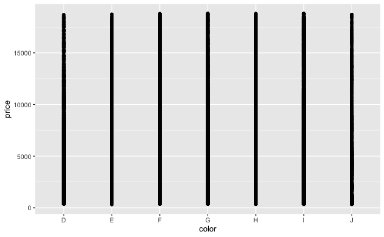

```r
diamonds_3 %>%
  ggplot(aes(x = color, y = price)) +
  geom_point() +
  geom_smooth(method = "lm", se = FALSE)
```

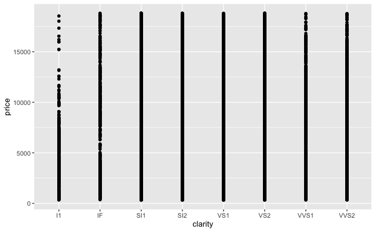

```r
diamonds_3 %>%
  ggplot(aes(x = clarity, y = price)) +
  geom_point() +
  geom_smooth(method = "lm", se = FALSE)
```

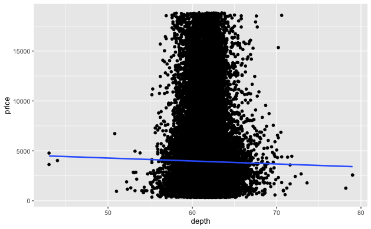

```r
diamonds_3 %>%
  ggplot(aes(x = depth, y = price)) +
  geom_point() +
  geom_smooth(method = "lm", se = FALSE)
```

```r
diamonds_3 %>%
  ggplot(aes(x = table, y = price)) +
  geom_point() +
  geom_smooth(method = "lm", se = FALSE)
```

[output not shown]

There is a big possitive correlation between price and carat (0.922), a small possitive one between price and table (0.127) and an almost inexistent negative one between price and depth (-0.0106).

cut –> 5 factor levels, 4 dummy variables clarity –> 8 factor levels, 7 dummy variables color –> 7 factor levels, 6 dummy variables

| X1 | carat | cut | color | clarity | depth | table | price | cut_Good | cut_Ideal | cut_Premium | cut_Very Good | clarity_IF | clarity_SI1 | clarity_SI2 | clarity_VS1 | clarity_VS2 | clarity_VVS1 | clarity_VVS2 | color_E | color_F | color_G | color_H | color_I | color_J |
| --- | --- | --- | --- | --- | --- | --- | --- | --- | --- | --- | --- | --- | --- | --- | --- | --- | --- | --- | --- | --- | --- | --- | --- | --- |
| 1 | 0.23 | Ideal | E | SI2 | 61.5 | 55.0 | 326 | 0 | 1 | 0 | 0 | 0 | 0 | 1 | 0 | 0 | 0 | 0 | 1 | 0 | 0 | 0 | 0 | 0 |
| 2 | 0.21 | Premium | E | SI1 | 59.8 | 61.0 | 326 | 0 | 0 | 1 | 0 | 0 | 1 | 0 | 0 | 0 | 0 | 0 | 1 | 0 | 0 | 0 | 0 | 0 |
| 3 | 0.23 | Good | E | VS1 | 56.9 | 65.0 | 327 | 1 | 0 | 0 | 0 | 0 | 0 | 0 | 1 | 0 | 0 | 0 | 1 | 0 | 0 | 0 | 0 | 0 |
| 4 | 0.29 | Premium | I | VS2 | 62.4 | 58.0 | 334 | 0 | 0 | 1 | 0 | 0 | 0 | 0 | 0 | 1 | 0 | 0 | 0 | 0 | 0 | 0 | 1 | 0 |
| 5 | 0.31 | Good | J | SI2 | 63.3 | 58.0 | 335 | 1 | 0 | 0 | 0 | 0 | 0 | 1 | 0 | 0 | 0 | 0 | 0 | 0 | 0 | 0 | 0 | 1 |
| 6 | 0.24 | Very Good | J | VVS2 | 62.8 | 57.0 | 336 | 0 | 0 | 0 | 1 | 0 | 0 | 0 | 0 | 0 | 0 | 1 | 0 | 0 | 0 | 0 | 0 | 1 |
| 7 | 0.24 | Very Good | I | VVS1 | 62.3 | 57.0 | 336 | 0 | 0 | 0 | 1 | 0 | 0 | 0 | 0 | 0 | 1 | 0 | 0 | 0 | 0 | 0 | 1 | 0 |
| 8 | 0.26 | Very Good | H | SI1 | 61.9 | 55.0 | 337 | 0 | 0 | 0 | 1 | 0 | 1 | 0 | 0 | 0 | 0 | 0 | 0 | 0 | 0 | 1 | 0 | 0 |
| 9 | 0.22 | Fair | E | VS2 | 65.1 | 61.0 | 337 | 0 | 0 | 0 | 0 | 0 | 0 | 0 | 0 | 1 | 0 | 0 | 1 | 0 | 0 | 0 | 0 | 0 |
| 10 | 0.23 | Very Good | H | VS1 | 59.4 | 61.0 | 338 | 0 | 0 | 0 | 1 | 0 | 0 | 0 | 1 | 0 | 0 | 0 | 0 | 0 | 0 | 1 | 0 | 0 |

[output cut: 990 more lines]

```r
model_6 <- lm(price ~ carat, data = diamonds_3)
summary(model)
```

[output not shown]

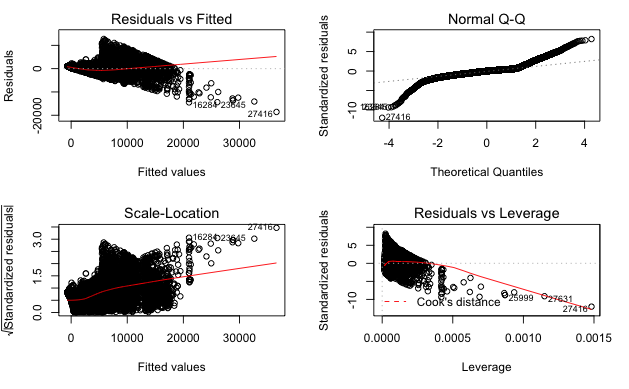

```r
par(mfrow = c(2, 2))
plot(model_6)
```

```r
model_7 <- lm(price ~ log(carat), data = diamonds_3)
summary(model_7)
```

```
Call:
lm(formula = price ~ log(carat), data = diamonds_3)

Residuals:
    Min      1Q  Median      3Q     Max
-6137.4 -1495.1  -328.3  1141.9 12075.3

Coefficients:
            Estimate Std. Error t value Pr(>|t|)
(Intercept)  6237.84      10.73   581.2   <2e-16 ***
log(carat)   5836.02      15.21   383.8   <2e-16 ***
---
Signif. codes:  0 ‘***’ 0.001 ‘**’ 0.01 ‘*’ 0.05 ‘.’ 0.1 ‘ ’ 1

Residual standard error: 2066 on 53938 degrees of freedom
Multiple R-squared:  0.7319,    Adjusted R-squared:  0.7319
F-statistic: 1.473e+05 on 1 and 53938 DF,  p-value: < 2.2e-16
```

It is worse (R decreased).

```r
model_8 <- lm(log(price) ~ carat, data = diamonds_3)
summary(model_8)
```

```
Call:
lm(formula = log(price) ~ carat, data = diamonds_3)

Residuals:
    Min      1Q  Median      3Q     Max
-6.2844 -0.2449  0.0335  0.2578  1.5642

Coefficients:
            Estimate Std. Error t value Pr(>|t|)
(Intercept) 6.215021   0.003348    1856   <2e-16 ***
carat       1.969757   0.003608     546   <2e-16 ***
---
Signif. codes:  0 ‘***’ 0.001 ‘**’ 0.01 ‘*’ 0.05 ‘.’ 0.1 ‘ ’ 1

Residual standard error: 0.3972 on 53938 degrees of freedom
Multiple R-squared:  0.8468,    Adjusted R-squared:  0.8468
F-statistic: 2.981e+05 on 1 and 53938 DF,  p-value: < 2.2e-16
```

Slightly worse.

```r
model_8 <- lm(log(price) ~ log(carat), data = diamonds_3)
summary(model_8)
```

```
Call:
lm(formula = log(price) ~ log(carat), data = diamonds_3)

Residuals:
     Min       1Q   Median       3Q      Max
-1.50833 -0.16951 -0.00591  0.16637  1.33793

Coefficients:
            Estimate Std. Error t value Pr(>|t|)
(Intercept) 8.448661   0.001365  6190.9   <2e-16 ***
log(carat)  1.675817   0.001934   866.6   <2e-16 ***
---
Signif. codes:  0 ‘***’ 0.001 ‘**’ 0.01 ‘*’ 0.05 ‘.’ 0.1 ‘ ’ 1

Residual standard error: 0.2627 on 53938 degrees of freedom
Multiple R-squared:  0.933, Adjusted R-squared:  0.933
F-statistic: 7.51e+05 on 1 and 53938 DF,  p-value: < 2.2e-16
```

Stronger correlation.

```r
model_9 <- lm(log(price) ~ log(carat) + cut, data = diamonds_3)
```

```r
summary(model_9)
```

```
Call:
lm(formula = log(price) ~ log(carat) + cut, data = diamonds_3)

Residuals:
     Min       1Q   Median       3Q      Max
-1.52247 -0.16484 -0.00587  0.16087  1.38115

Coefficients:
             Estimate Std. Error t value Pr(>|t|)
(Intercept)  8.200125   0.006343 1292.69   <2e-16 ***
log(carat)   1.695771   0.001910  887.68   <2e-16 ***
cutGood      0.163245   0.007324   22.29   <2e-16 ***
cutIdeal     0.317212   0.006632   47.83   <2e-16 ***
cutPremium   0.238217   0.006716   35.47   <2e-16 ***
cutVery Good 0.240753   0.006779   35.52   <2e-16 ***
---
Signif. codes:  0 ‘***’ 0.001 ‘**’ 0.01 ‘*’ 0.05 ‘.’ 0.1 ‘ ’ 1

Residual standard error: 0.2545 on 53934 degrees of freedom
Multiple R-squared:  0.9371,    Adjusted R-squared:  0.9371
F-statistic: 1.607e+05 on 5 and 53934 DF,  p-value: < 2.2e-16
```

```r
model_10 <- lm(log(price) ~ log(carat) + color, data = diamonds_3)
```

```r
summary(model_10)
```

```
Call:
lm(formula = log(price) ~ log(carat) + color, data = diamonds_3)

Residuals:
     Min       1Q   Median       3Q      Max
-1.49987 -0.14888  0.00257  0.15316  1.27815

Coefficients:
             Estimate Std. Error  t value Pr(>|t|)
(Intercept)  8.572034   0.003051 2809.531  < 2e-16 ***
log(carat)   1.728631   0.001814  952.727  < 2e-16 ***
colorE      -0.025460   0.003748   -6.793 1.11e-11 ***
colorF      -0.034455   0.003773   -9.132  < 2e-16 ***
colorG      -0.055399   0.003653  -15.166  < 2e-16 ***
colorH      -0.189859   0.003917  -48.468  < 2e-16 ***
colorI      -0.286928   0.004383  -65.467  < 2e-16 ***
colorJ      -0.425038   0.005417  -78.466  < 2e-16 ***
---
Signif. codes:  0 ‘***’ 0.001 ‘**’ 0.01 ‘*’ 0.05 ‘.’ 0.1 ‘ ’ 1

Residual standard error: 0.2372 on 53932 degrees of freedom
Multiple R-squared:  0.9454,    Adjusted R-squared:  0.9454
F-statistic: 1.333e+05 on 7 and 53932 DF,  p-value: < 2.2e-16
```

```r
model_11 <- lm(log(price) ~ log(carat) + clarity, data = diamonds_3)
```

```r
summary(model_11)
```

[output not shown]